# Initial data analysis - Project 3

Saibal Bhattacharya

**Prework: Load the CSV file and libraries.**

```r
library(tidyverse)
library(data.table)
library(hrbrthemes)
library(lubridate)
library(chron)
```

```r
library(data.table)
library(ggplot2)
library(repr)
library(dplyr)
library(caret)
df1 <- read.csv("PROJECT3_DATA.csv")

# Set the initial plot area dimensions
options(repr.plot.width=4, repr.plot.height=4)
```

**Given this data, is it possible to predict what user group and/or location a user is tied to based on login time and session duration?**

```r
#---------------------- Initial review of data -----------------------------

#Check class of object
class(df1)
```

```
## [1] "data.frame"
```

```r
#Check mode of object, i.e., how an object is stored in memory (numeric, character, list and function)
mode(df1)
```

```
## [1] "list"
```

```r
#Check data summary
summary(df1)
```

```
##  attemptdate        attemptresult         userid              type
##  Length:53046       Length:53046       Length:53046       Length:53046
##  Class :character   Class :character   Class :character   Class :character
##  Mode  :character   Mode  :character   Mode  :character   Mode  :character
##
##
##
##    defsite           groupname         maxsessionuid
##  Length:53046       Length:53046       Min.   :873258
##  Class :character   Class :character   1st Qu.:882813
##  Mode  :character   Mode  :character   Median :890036
##                                        Mean   :889864
##                                        3rd Qu.:896689
##                                        Max.   :904631
```

**Observation:** All columns except maxsessionuid are character - maxsessionuid is numeric.

```r
#view data table
#View(df1)
```

**Observation:** Maxsessionid - no NA or missing values present

```r
#check types of jobtitles (groupname) and their locations (defsite)
table(df1$defsite)
```

```
##
##      LA LA_PIPE OK_PIPE      TX TX_PIPE
##   32677     124      37   20165      43
```

**Observation:** LA & LA_PIPE and TX & TA_PIPE make up vast majority of data OK_PIPE has only 37 cases - insufficient to train and test Need to remove OK_PIPE to reduce imbalance

```r
#keep only unique rows - How many unique userids are present?
#keep_all = TRUE - will keep all columns
df2 <- df1 %>% distinct(userid, .keep_all = TRUE)

#summarize unique no of users under title "no_of_unique_users"
df2 %>% summarise(no_of_unique_users = n())
```

```
##   no_of_unique_users
## 1                572
```

**Observation:** There are 572 unique userids

```r
#extracting distinct maxsessionuid
#Expectation: 1st mention of a maxsessionuid should be a LOGIN
#So under attemptresult one should only see LOGINs
df3 <- df1 %>% distinct(maxsessionuid, .keep_all = TRUE)

#Find number of maxsessionuid that are not tied to a LOGIN
table(df3$attemptresult)
```

```
##
##     LOGIN   RESTART SYSLOGOUT
##     25392         1         4
```

**Observation:** There are 25392 LOGINs, 1 RESTART, and 4 SYSLOGOUT

```r
#------------------------- Initial data cleanup ----------------
#Cleaning up dataset - removing SYSLOGOUTs (as per advice from client)
df4 <- df1 %>% filter(attemptresult != "SYSLOGOUT")

#Convert to data table (DT)
df5 <- setDT(df4)

#Order by sessionID and then by my_time
df6 <- df5 %>% arrange(maxsessionuid, attemptdate)
nrow(df6)
```

```
## [1] 50785
```

```r
#Remove duplicate rows
df6b <- unique( df6[ , 1:7 ] )
nrow(df6b)
```

```
## [1] 50768
```

```r
# add an 'order' column, which is a sequence from 1 to N, i.e., length() for each sessionID
df7 <- df6b[, order := seq(1:.N), by=maxsessionuid]
table(df7$order)
```

```
##
##     1     2     3     4
## 25393 25320    34    21
```

**Observation:** There are 25393 cases of order = 1, and 25320 cases of order = 2. There are 34 cases of order = 3 and 21 cases of order = 4. For order = 4, same user has logged under different grpname at same time.

Ideally, each sessionID should have a LOGIN and a LOGOUT/RESTART/TIMEOUT For each sessionID, LOGINs should have order = 1, and vast majority of LOGINs do have that For each sessionID, LOGOUT/RESTART/TIMEOUT should have order = 2. Order = 2 is mostly for LOGOUT and TIMEOUT. In a small minority of cases we have order = 3 and 4

```r
table(df7$order, df7$attemptresult)
```

```
##
##     LOGIN LOGOUT RESTART TIMEOUT
##   1 25390      0       1       2
##   2    24   9455      16   15825
##   3     0     24       0      10
##   4     0     16       0       5
```

```r
# Building file with only LOGINs
df7_login <- df7[attemptresult == "LOGIN"]
table(df7_login$attemptresult)
```

```
##
## LOGIN
## 25414
```

```r
# Build file with only different types of LOGOUT including: LOGOUT, TIMEOUT, and RESTART
df7_logout <- df7[attemptresult == "LOGOUT" | attemptresult == "TIMEOUT" | attemptresult == "RESTART"]
table(df7_logout$attemptresult)
```

```
##
##  LOGOUT RESTART TIMEOUT
##    9495      17   15842
```

```r
# assuming LOGOUT, RESTART, and TIMEOUT will always happen after LOGIN for a sessionID
# So shift the 'order' number for LOGOUT, TIMEOUT, and RESTART back by 1
# So that it matches 'order' number of LOGIN
# But subtracting 1 where LOGOUT, TIMEOUT, and RESTART = 1 will make it zero - so dt_logout should only have zero values.
df7_logout[, order := order - 1]
table(df7_logout$attemptresult, df7_logout$order)
```

```
##
##               0     1     2     3
##   LOGOUT      0  9455    24    16
##   RESTART     1    16     0     0
##   TIMEOUT     2 15825    10     5
```

**Observation:** Most order values are 1, but there are some order = 2 and 3 present

```r
# Join tables on sessionID, order number, type, userid, defsite, and groupname
# Columns to keep - sessionID, order, type, userid, defsite, groupname, and attemptdate
# Use NA if attemptdate not present in dt_login or dt_logout
df8 <- df7_login[, .(maxsessionuid, order, type, userid, defsite, groupname, attemptdate)][df7_logout[, .(maxsessionuid, order, type, userid, defsite, groupname, attemptdate)],on = c("maxsessionuid", "order", "type", "userid", "defsite", "groupname"), nomatch=NA]
table(df8$order)
```

```
##
##     0     1     2     3
##     3 25296    34    21
```

**Observation:** Vast majority of cases are for order = 1 As expected, 25296 cases for order = 1, 34 for order = 2, and 21 for order = 3

```r
# rename columns
df9 <- setnames(df8, c("attemptdate", "i.attemptdate"), c("LOGIN_time", "Out_time"))

#check number of NAs in LOGIN column
sum(is.na(df9$LOGIN_time))
```

```
## [1] 57
```

**Observation:** There are 57 NAs in LOGIN_time

```r
#remove all rows where LOGIN_time = NA
df10 <- df9[!is.na(df9$LOGIN_time), ]
summary(df10)
```

```
##  maxsessionuid        order       type              userid
##  Min.   :873260   Min.   :1   Length:25297       Length:25297
##  1st Qu.:882771   1st Qu.:1   Class :character   Class :character
##  Median :890027   Median :1   Mode  :character   Mode  :character
##  Mean   :889828   Mean   :1
##  3rd Qu.:896659   3rd Qu.:1
##  Max.   :904631   Max.   :2
##    defsite           groupname          LOGIN_time          Out_time
##  Length:25297       Length:25297       Length:25297       Length:25297
##  Class :character   Class :character   Class :character   Class :character
##  Mode  :character   Mode  :character   Mode  :character   Mode  :character
##
##
##
```

**Observation:** All columns, except maxsessionuid and order, are character

```r
#check class
class(df10)
```

```
## [1] "data.table" "data.frame"
```

```r
#convert time from character to POSIXct object
df11 <- df10 %>% mutate(my_LOGIN_time = mdy_hm(df10$LOGIN_time), my_Out_time = mdy_hm(df10$Out_time))

#Add a column for session time in minutes
df11$sessiontime <- round((df11$my_Out_time - df11$my_LOGIN_time)/60, 2)

#Remove time columns where time is shown as character
df12 <- df11 %>% select(-LOGIN_time, -Out_time)

#See summary of a difftime - need to convert it to numeric
summary(as.numeric(df12$sessiontime))
```

```
##    Min. 1st Qu.  Median    Mean 3rd Qu.    Max.
##    0.00    4.00   29.00   33.83   40.00 1246.00
```

```r
#Check distribution of session times - check for session time = zero
table(df12$sessiontime)
```

```
##
##    0    1    2    3    4    5    6    7    8    9   10   11   12   13   14   15
## 2045  569  671 1669 2334  774  454  416  336  334  270  261  198  217  205  164
##   16   17   18   19   20   21   22   23   24   25   26   27   28   29   30   31
##  175  159  139  134  123  132  114  112  119  123  110   92  115   92 1922 1251
##   32   33   34   35   36   37   38   39   40   41   42   43   44   45   46   47
##  764  492  396  368  283  286  243  237  214  201  209  191  160  190  171  130
##   48   49   50   51   52   53   54   55   56   57   58   59   60   61   62   63
##  132  152  112  109   99  118  122  113  103  121   97   98   94   87   95   98
##   64   65   66   67   68   69   70   71   72   73   74   75   76   77   78   79
##   71   68   78   62   71   60   55   51   60   62   71   51   46   51   40   48
##   80   81   82   83   84   85   86   87   88   89   90   91   92   93   94   95
##   48   39   49   50   30   48   34   42   46   35   38   47   30   38   33   32
##   96   97   98   99  100  101  102  103  104  105  106  107  108  109  110  111
##   23   31   43   20   25   30   26   26   17   22   21   18   15   18   15   23
```

[output cut: 38 more lines]

**Observation** There are lots of session times = zero mins Assumption: No real work gets done if session time = zero mins So session time = zero are considered accidental login that don’t affect obj functions

```r
#Thus, removing all session time = zero
df12b <- df12[as.numeric(sessiontime) != 0]

#Convert select character columns to factor
df13 <- mutate_at(df12b, vars('type', 'defsite', 'groupname'), as.factor)

#Extract hr, day, weekday/weekend from login time and save in new columns
df13$login_hr <- hour(as.POSIXlt(df13$my_LOGIN_time))
df13$login_day <- day(as.POSIXlt(df13$my_LOGIN_time))
df13$login_wday <- weekdays(as.POSIXlt(df13$my_LOGIN_time))
#Weekends are TRUE
df13$weekend = chron::is.weekend(df13$my_LOGIN_time)

#Lump TX and TX_PIPE into one category called TX_all
df13$defsite_grp[df13$defsite == "TX"] <- "TX_all"
df13$defsite_grp[df13$defsite == "TX_PIPE"] <- "TX_all"

#Lump LA and LA_PIPE into one category called LA_all
df13$defsite_grp[df13$defsite == "LA"] <- "LA_all"
df13$defsite_grp[df13$defsite == "LA_PIPE"] <- "LA_all"

#Redefine OK_PIPE as OK_all under defsite_grp
df13$defsite_grp[df13$defsite == "OK_PIPE"] <- "OK_all"

#Remove OK_all rows - too few cases for training and testing
df13b <- subset(df13, defsite_grp != "OK_all")

#check number of TX_all, and LA_all cases - shouldn't have OK_all
table(df13b$defsite_grp)
```

```
##
## LA_all TX_all
##  14668   8572
```

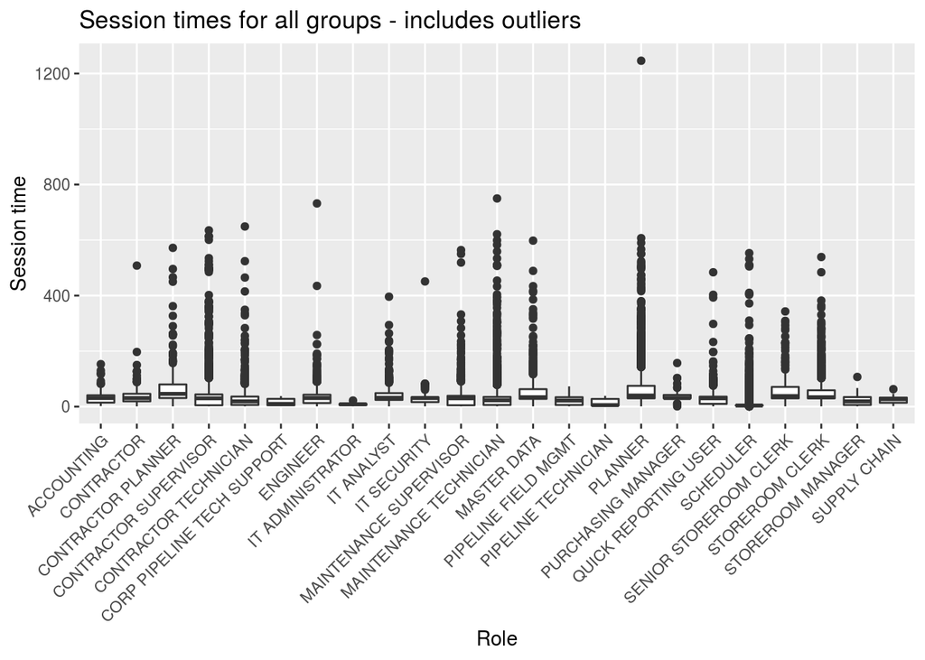

```r
#Compare LA_all and TX_all using Box plots - includes outliers
ggplot(df13b, aes(x=groupname, y=as.numeric(sessiontime))) +
  labs(y="Session time", x = "Role") +
  ggtitle("Session times for all groups - includes outliers") +
  geom_boxplot() + theme(axis.text.x = element_text(angle = 45, hjust = 1))
```

```r
#Identify & remove outliers
#Define outlier based on IQR (inter quartile range) - returns TRUE for outlier
outlier <- function(x) {
  ifelse(x < quantile(x, 0.25) - 1.5 * IQR(x) | x > quantile(x, 0.75) + 1.5 * IQR(x),
         TRUE,
         FALSE)
}
#library(data.table) - already inserted at the beginning
#apply the outlier function per group and report status under outlier_ident
df13c <- setDT(df13b)[, outlier_ident := outlier(sessiontime), by = 'defsite_grp']
view(df13c)
#Remove outliers
df13_no_out <- df13c[outlier_ident == FALSE]
table(df13_no_out$defsite_grp)
```

```
##
## LA_all TX_all
##  13736   7929
```

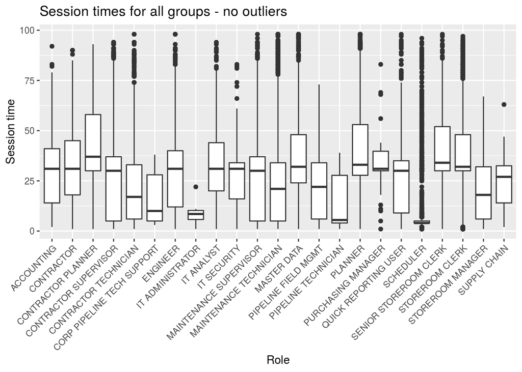

```r
#Create boxplots for all - excluding outliers
ggplot(df13_no_out, aes(x=groupname, y=as.numeric(sessiontime))) +
  labs(y="Session time", x = "Role") +
  ggtitle("Session times for all groups - no outliers") +
  geom_boxplot() + theme(axis.text.x = element_text(angle = 45, hjust = 1))
```

```r
#Select data where defsite_grp = LA_all (excludes outliers)
df14_LA_no_out <- df13_no_out[defsite_grp == "LA_all"]

#Summary statistics on sessiontime from LA_all (excludes outliers)
round(mean(as.numeric(df14_LA_no_out$sessiontime)),2)
```

```
## [1] 24.32
```

```r
round(median(as.numeric(df14_LA_no_out$sessiontime)),2)
```

```
## [1] 21
```

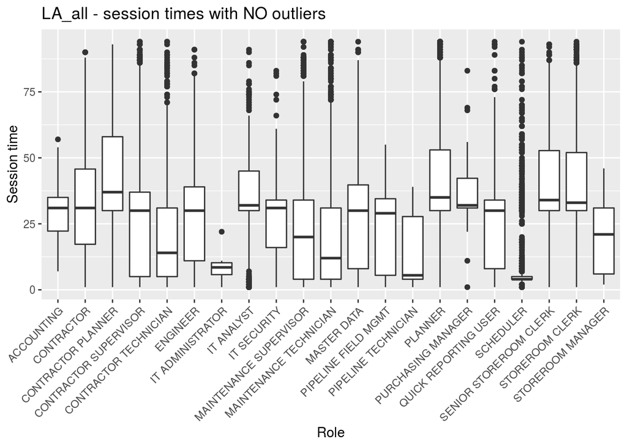

```r
#Box plot for LA_all - session times per groupname (excludes outliers)
ggplot(df14_LA_no_out, aes(x=groupname, y=as.numeric(sessiontime))) +
  labs(y="Session time", x = "Role") +
  ggtitle("LA_all - session times with NO outliers") +
  geom_boxplot() + theme(axis.text.x = element_text(angle = 45, hjust = 1))
```

```r
#Select data where defsite_grp = TX_all (excludes outliers)
df14_TX_no_out <- df13_no_out[defsite_grp == "TX_all"]

#Summary statistics on sessiontime from TX_all (excludes outliers)
round(mean(as.numeric(df14_TX_no_out$sessiontime)),2)
```

```
## [1] 30.1
```

```r
round(median(as.numeric(df14_TX_no_out$sessiontime)),2)
```

```
## [1] 30
```

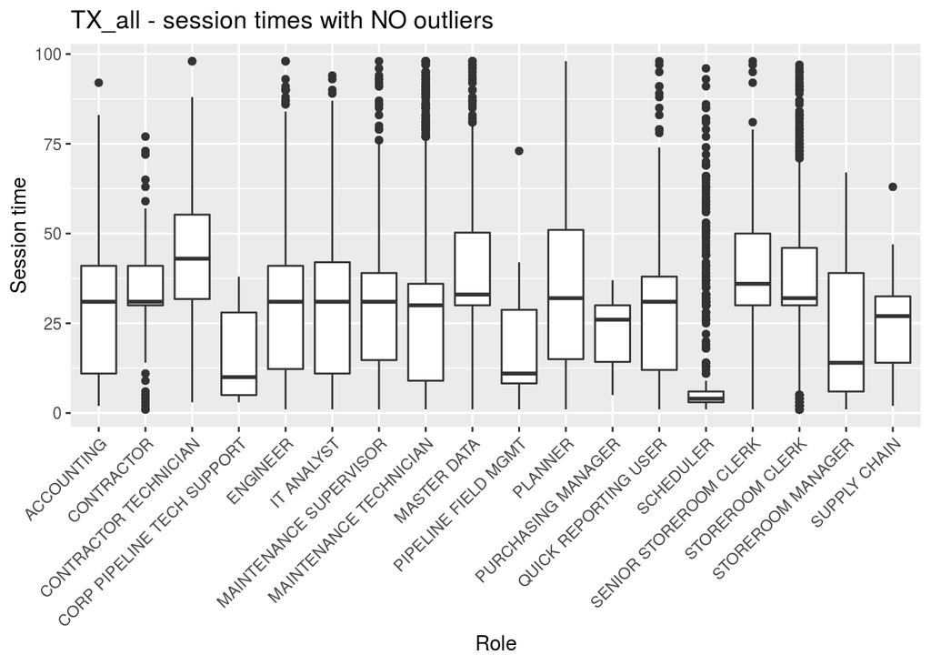

```r
#Box plot for TX_all - session times per groupname (excludes outliers)
ggplot(df14_TX_no_out, aes(x=groupname, y=as.numeric(sessiontime))) +
  labs(y="Session time", x = "Role") +
  ggtitle("TX_all - session times with NO outliers") +
  geom_boxplot() + theme(axis.text.x = element_text(angle = 45, hjust = 1))
```

```r
#Convert to data frame (DF)
df15_no_out <- setDF(df13_no_out)

#Convert weekend logical values (TRUE = weekends = 1 & FALSE = weekdays = 0) to 1 and 0
df15_no_out$weekend_num <- as.numeric(df15_no_out$weekend)

#Convert session time to numeric (from difftime) - very important
df15_no_out$sessiontime_num <- as.numeric(df15_no_out$sessiontime)

#Convert defsite_grp to factor
df15_no_out <- mutate_at(df15_no_out, vars('defsite_grp'), as.factor)

#Number of distinct groupnames
length(unique(df15_no_out$groupname))
```

```
## [1] 23
```

**Observation:** There are 23 kinds of groupname - each with widely different no of cases This will create imbalance for training and testing. So groupnames need to be lumped - following guidance from client (Freddy).

```r
#Lumping groupname with client guidance - reducing groupname from 23 to 6
df15_no_out$groupname_bin[df15_no_out$groupname %in% c('IT SECURITY', 'IT ADMINISTRATOR', 'IT ANALYST')] <- 'IT'
df15_no_out$groupname_bin[df15_no_out$groupname %in% c('CORP PIPELINE TECH SUPPORT', 'PIPELINE FIELD MGMT','PIPELINE TECHNICIAN')] <- 'PIPELINE'
df15_no_out$groupname_bin[df15_no_out$groupname %in% c('CONTRACTOR PLANNER', 'PLANNER' , 'SCHEDULER')] <- 'PLANNING'
df15_no_out$groupname_bin[df15_no_out$groupname %in% c('CONTRACTOR', 'ENGINEER', 'QUICK REPORTING USER')] <- 'OPERATIONS'
df15_no_out$groupname_bin[df15_no_out$groupname %in% c('MASTER DATA', 'MAINTENANCE TECHNICIAN', 'CONTRACTOR TECHNICIAN', 'MAINTENANCE SUPERVISOR', 'CONTRACTOR SUPERVISOR')] <- 'MAINTENANCE'
df15_no_out$groupname_bin[df15_no_out$groupname %in% c('ACCOUNTING', 'PURCHASING MANAGER', 'SUPPLY CHAIN', 'STOREROOM MANAGER', 'STOREROOM CLERK', 'SENIOR STOREROOM CLERK')] <- 'SUPPLY CHAIN'

table(df15_no_out$groupname_bin)
```

```
##
##           IT  MAINTENANCE   OPERATIONS     PIPELINE     PLANNING SUPPLY CHAIN
##          597        10687         2170           76         5816         2319
```

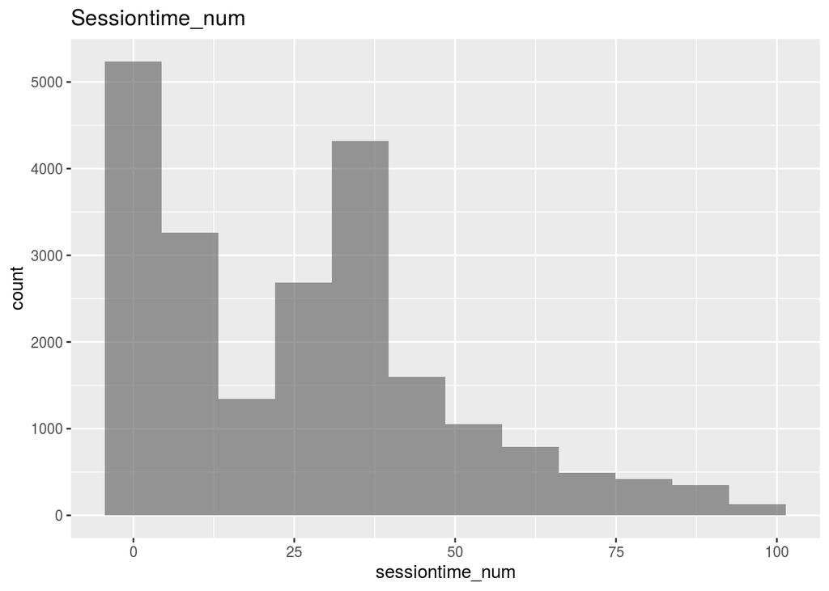

```r
#Display histogram of sessiontime_num
plot_hist = function(df, numcols, bins = 10){
  options(repr.plot.width=4, repr.plot.height=3) # Set the initial plot area dimensions
  for(col in numcols){
    if(is.numeric(df[,col])){
      bw = (max(df[,col]) - min(df[,col]))/(bins + 1)
      p = ggplot(df, aes_string(col)) + ggtitle("Sessiontime_num") +
        geom_histogram(alpha = 0.6, binwidth = bw)
      print(p)
    }
  }
}

numcols = c('sessiontime_num')
plot_hist(df15_no_out, numcols)
```

**Observation:** The histogram in NOT normal - it is bi-modal

```r
#Convert groupname_bin to factor
df15_no_out <- mutate_at(df15_no_out, vars('groupname_bin'), as.factor)

#Convert groupname_bin to numbers (i.e., gname_bin_num)
df15_no_out$gname_bin_num <- ifelse(df15_no_out$groupname_bin == "IT", 1,
               ifelse(df15_no_out$groupname_bin == "MAINTENANCE", 2,
                      ifelse(df15_no_out$groupname_bin == "OPERATIONS", 3,
                             ifelse(df15_no_out$groupname_bin == "PIPELINE", 4,
                                    ifelse(df15_no_out$groupname_bin == "PLANNING", 5,
                                           ifelse(df15_no_out$groupname_bin == "SUPPLY CHAIN", 6,
                                                  NA ))))))

table(df15_no_out$gname_bin_num)
```

```
##
##     1     2     3     4     5     6
##   597 10687  2170    76  5816  2319
```

**Observation:** End of initial data analysis and cleanup

```r
#Rename dataframe after initial analysis
df16_no_out <- df15_no_out
```